# Teacher’s salaries and SAT scores

some Smith students (Group D)

12/15/2014

#### Abstract

The purpose of this study is to investigate the relationship between average teachers salary and average SAT scores per state in the US using census data from the 2012-2013 academic year. We would assume that better pay for teachers lead to greater academic success for their students. We completed a multiple linear regression model to look at the relationship between average teacher’s salary and SAT scores per state, controlling for average family income, student teacher ratio, high school graduation rate, and percentage of high school students that took the SAT per state. We found that there was no statistically significant evidence that there was a relationship between average teacher’s salary and average SAT score per state in the 2012-2013 academic year. Our model revealed that student SAT scores are significantly related to average family income, graduation rate, and the percentage of high school students that took the test.

#### Introduction

Does a teacher’s salary have an effect on their student’s academic sucess? The purpose of our study was to answer this question using average SAT scores per state as a measure of success. We predicted that higher pay for teachers would cause them to invest more time into their jobs, which would translate into better grades for their students.We used the 50 states of the United States as well as the Distric of Columbia as our cases. Because we used a census, rather than a sample of states, we could not make any inferences about population.  
In addition to identifying a relationship (or lack thereof) between average teacher salary per state and average SAT scores per state, we also determined if average family income, student/teacher ratio, graduation rate, and the percentage of high school students that took the SAT per state had any effect on average SAT scores. We analyzed this data using multiple linear regression, and used the p-values to determine if the variables were statistically significant in determining SAT scores using an alpha level 0.05.

Our hypotheses are as follows:  
**H0:** There is no relationship between teacher’s salary and SAT scores  
**HA:** An increase in teacher’s salary results in an increase in SAT scores

#### Data

We obtained data for our response variable, average SAT scores (out of 2400) of all the SAT test takers per state from the Collegeboard website. Our explanatory variables include; average teacher’s salary (dollars) per state which was obtained from the website of the National Center for Education Statistics, average household income (dollars) per state was taken from the National Census Bureau,the percentage of high school students that took the SAT per state was obtained from the collegeboard website, the student teacher ratio and the graduation rate was taken from the National Education Association website. All the data was obtained was from the 2012-2013 school year. Our data was not sampled, they were taken in a census, therefore since we have data for the whole population, we don’t need to make inferences e.g. confidence intervals, e.t.c.

#### Results

```r
require(mosaic)
dsat3 <- read.csv(file="/Users/fbassir/dsat3.csv", head=TRUE, sep=",")
```

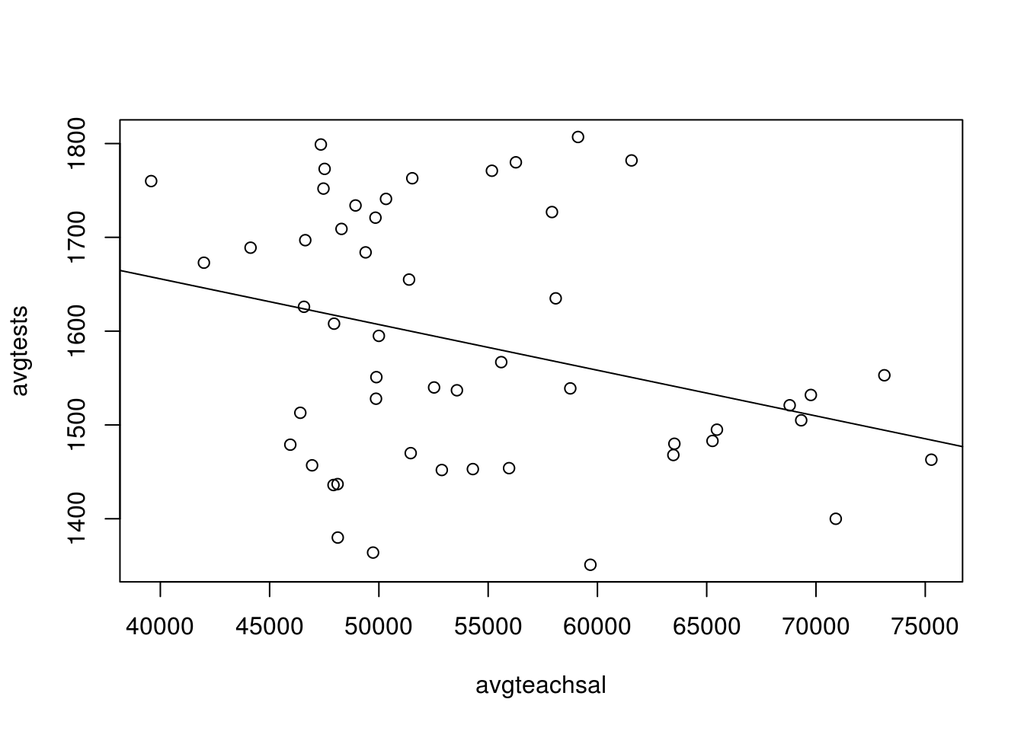

```r
plot1 <- lm(avgtests~avgteachsal, data= dsat3)
plot(avgtests~avgteachsal, data= dsat3)
abline(plot1)
```

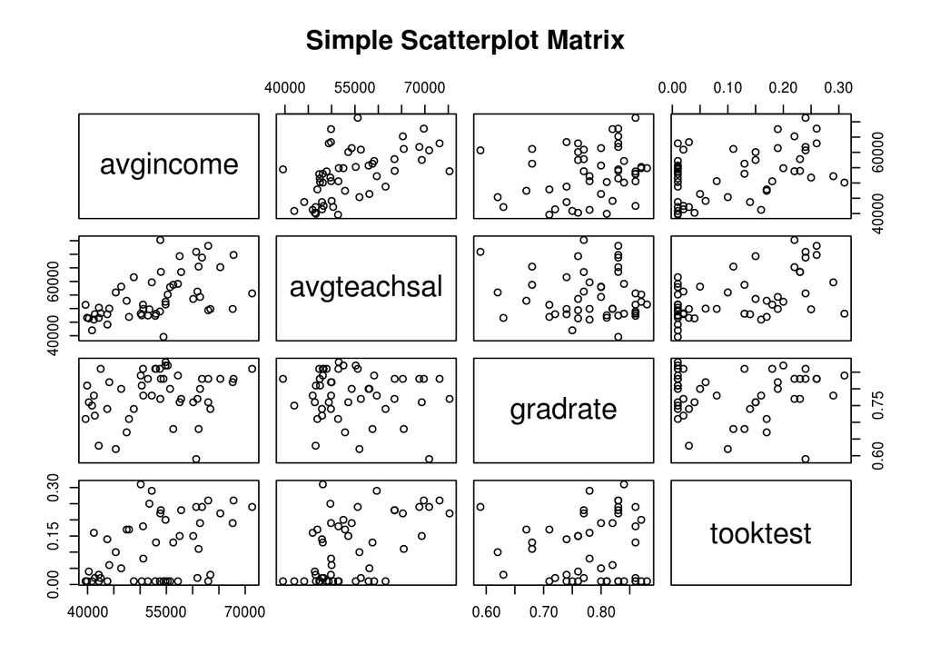

```r
pairs(~avgincome+avgteachsal+gradrate+tooktest,data=dsat3, main="Simple Scatterplot Matrix")
```

#### Results

```r
all = lm(avgtests ~ avgteachsal + avgincome + studteach + gradrate + tooktest, data = dsat3)
summary(all)
```

```
##
## Call:
## lm(formula = avgtests ~ avgteachsal + avgincome + studteach +
##     gradrate + tooktest, data = dsat3)
##
## Residuals:
##    Min     1Q Median     3Q    Max
## -149.3  -28.6   11.4   28.6   82.2
##
## Coefficients:
##              Estimate Std. Error t value Pr(>|t|)
## (Intercept)  1.03e+03   1.08e+02    9.57  4.1e-12 ***
## avgteachsal  2.08e-03   1.20e-03    1.73   0.0915 .
## avgincome    3.63e-03   1.13e-03    3.20   0.0026 **
## studteach   -7.04e-02   1.50e+00   -0.05   0.9627
## gradrate     5.08e+02   1.13e+02    4.49  5.4e-05 ***
## tooktest    -1.35e+03   9.64e+01  -14.03  < 2e-16 ***
## ---
## Signif. codes:  0 '***' 0.001 '**' 0.01 '*' 0.05 '.' 0.1 ' ' 1
##
## Residual standard error: 50.4 on 42 degrees of freedom
##   (3 observations deleted due to missingness)
## Multiple R-squared:  0.868,  Adjusted R-squared:  0.852
## F-statistic:   55 on 5 and 42 DF,  p-value: <2e-16
```

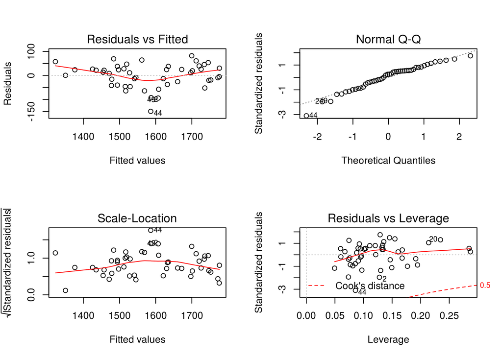

```r
par(mfrow=c(2,2))
plot(all)
```

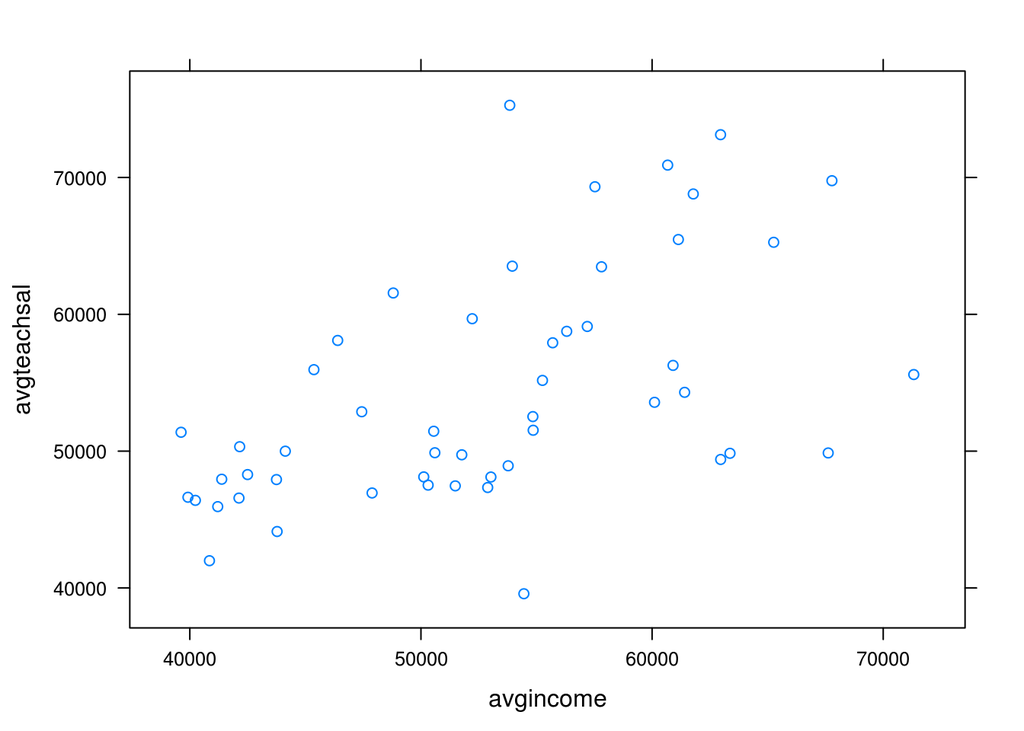

```r
all2 <- lm(avgteachsal~avgincome, data= dsat3)
xyplot(avgteachsal~avgincome, data= dsat3)
```

```r
summary(all2)
```

```
##
## Call:
## lm(formula = avgteachsal ~ avgincome, data = dsat3)
##
## Residuals:
##    Min     1Q Median     3Q    Max
## -15636  -4775   -932   5044  20401
##
## Coefficients:
##             Estimate Std. Error t value Pr(>|t|)
## (Intercept) 2.50e+04   6.60e+03    3.79  0.00041 ***
## avgincome   5.54e-01   1.23e-01    4.49  4.3e-05 ***
## ---
## Signif. codes:  0 '***' 0.001 '**' 0.01 '*' 0.05 '.' 0.1 ' ' 1
##
## Residual standard error: 7240 on 49 degrees of freedom
## Multiple R-squared:  0.292,  Adjusted R-squared:  0.277
## F-statistic: 20.2 on 1 and 49 DF,  p-value: 4.33e-05
```

*Linearity* - We use the residual versus fitted plot te determine linearity. Residuals bounce equally around the line at 0.

*Independence* - We assumed that all observations are independent; students who take SAT in one state do not take the SAT in another state.

*Normalty of residuals* - The Normal Q-Q plot shows that the residuals follow a normal distribution, except for residuals at the very end and at the very beginning of the spread.

*Equal Variance* - The variances of the error terms are equal. In the residual versus fitted plot, they form a horizontal band.

The residuals vs. leverage plot shows that the outliers in our data are not influential points since they do not have high leverage by the Cook’s test.

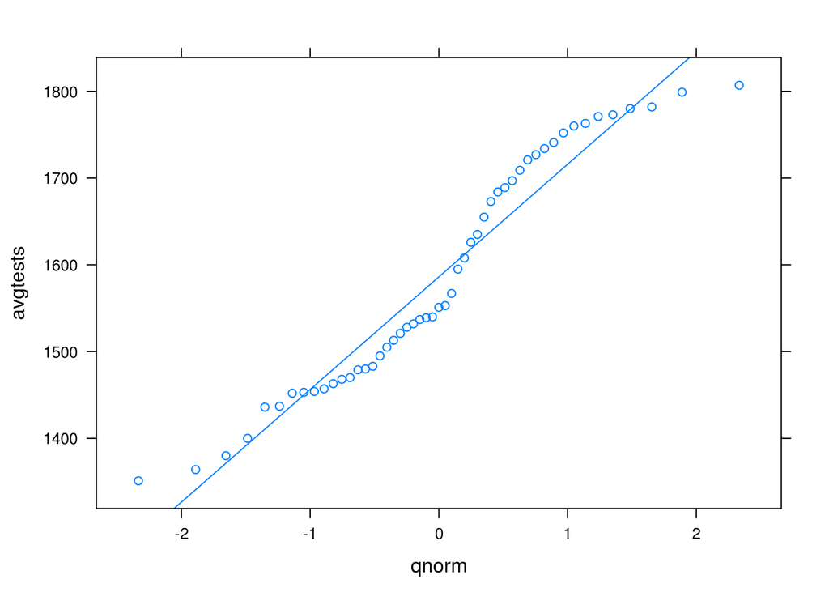

```r
qqmath(~avgtests, data= dsat3, type=c("p", "r"))
```

A univariate analysis of our response varieable, average test scores, shows that its distribution is fairly normal with some variations.

#### Conclusion

The model had some weaknesses as it does not account for the cost of living which varies significantly from state to state. Other variables such as ratio of public to private schools, ethnicity, crime rate, population density e.t.c. that we have not controlled might be related to the average SAT score. Even though we find a statistically significant relationship between average income, average graduation rate and percentage of students that took test we cannot imply causation. In order for us to imply causation, we would have to conduct a controlled experiment in which we varied teacher’s salaries.

After completing our study, we later found a possible discrepancy in our data. We learned that many midwestern states prefer the ACT over the SAT. Therefore, very few students take the SAT’s in these states, and the few that due are usually the states’ top tier students. This results in a higher average SAT score for these states in comparison to coastal states where most students take the SAT, regardless of class rankings. Since we conducted this study to determine a student’s academic sucess on average, using SAT scores as a measure of success, in the future we would also include average ACT scores in our data. We would normalize the ACT scores so they can be compared to SAT scores on the same scale to get more wholistic view on the relationship between average teacher’s salary and student academic performance.

References:

1. “New Study: Merit Pay Does Not Boost Student Achievement - NEA Today.”NEA Today. N.p., 21 Sept. 2010. Web. 16 Dec. 2014.
2. “Teacher Performance Pay Alone Does Not Raise Student Test Scores.”Vanderbilt News. N.p., n.d. Web. 16 Dec. 2014.